# A3: SPL Library Checkouts

Sadeem Alselmi

### Introduction

The dataset is from the Seattle Public Library and contains items checked out at least 10 times a month from 2017-2023. In this report, I will focus on analyzing the trends of books checked out by material type and medium. The variables I will use in my analysis include checkout year, material type, medium, and the total number of checkouts. I will look at how the number of checkouts for each item has changed over time, which books and mediums have the most/least checkouts, and how the number of print book checkouts has changed over time.

### The Dataset

It is a collection of checkout records from the Seattle Public Library (SPL). The data includes information on items that were checked out at least 10 times a month between the years 2017-2023. The parameters of the data include checkout year, material type, medium, title, author, and the total number of checkouts. The Seattle Public Library collected and published this data in order to provide insights into the trends of items that were being checked out from their library. The data was collected through the use of the library’s checkout and circulation systems, which recorded the checkout activity of their patrons. When working with this dataset, it is important to consider ethical questions related to the privacy of library patrons. It is crucial to avoid analyzing individual checkout records and instead focus on the overall trends of checkouts by material type and medium. The SPL has likely taken measures to ensure that the data is anonymous, but it is still important to approach the analysis with care and respect for the privacy of the library patrons. There are several limitations and problems that must be considered when working with this data. One limitation is that the dataset only includes items that were checked out at least 10 times a month. This means that some items with lower checkouts may not be represented in the dataset, and may not provide an accurate picture of the library’s overall circulation. Additionally, the data only includes items from the Seattle Public Library, which may not be representative of trends in other libraries or regions. Finally, the dataset does not include information on the demographics of the library patrons who checked out the items, which limits our ability to draw conclusions about who is using the library and why. In conclusion, the Seattle Public Library’s dataset provides valuable insights into the trends of items checked out from their library. However, when working with this data, it is important to approach the analysis with care and respect for the privacy of library patrons. It is also important to keep in mind the limitations and problems associated with the dataset, and to consider how these factors may impact the conclusions that can be drawn from the data.

### Chart 1: Yearly Circulation Trends of BOOKS and EBOOKS

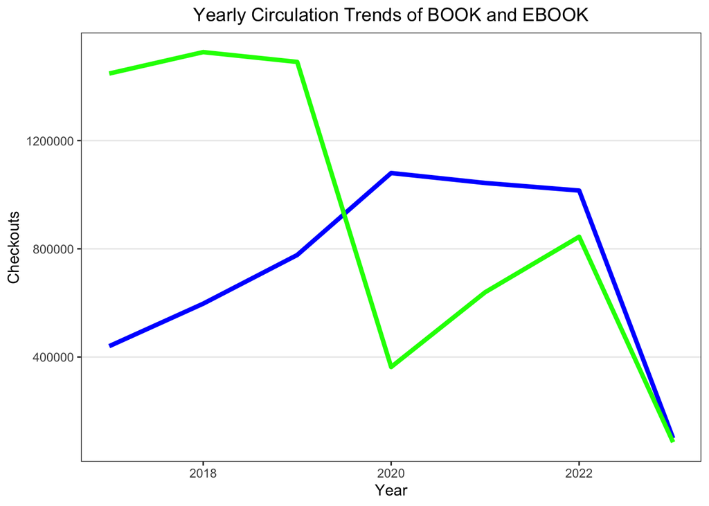

The first chart in the analysis displays yearly circulation trends of books and ebooks from 2017 to 2023. I included this chart to visualize the trends in checkout activity for these two popular material types and provide insights into the evolving preferences of library users.

The inclusion of this chart is essential in providing librarians and book publishers with valuable insights into the circulation trends of books and ebooks. The data can be used to make informed decisions about the allocation of resources towards digital materials and the expansion of the library’s collection to meet the evolving needs and preferences of library users.

Overall, the first chart provides crucial information regarding the circulation trends of books and Ebooks over time. The data can assist libraries and publishers in making data-driven decisions about their collection and resource allocation to meet the changing needs of their patrons.

### Chart 2: Yearly Circulation Trends by Medium

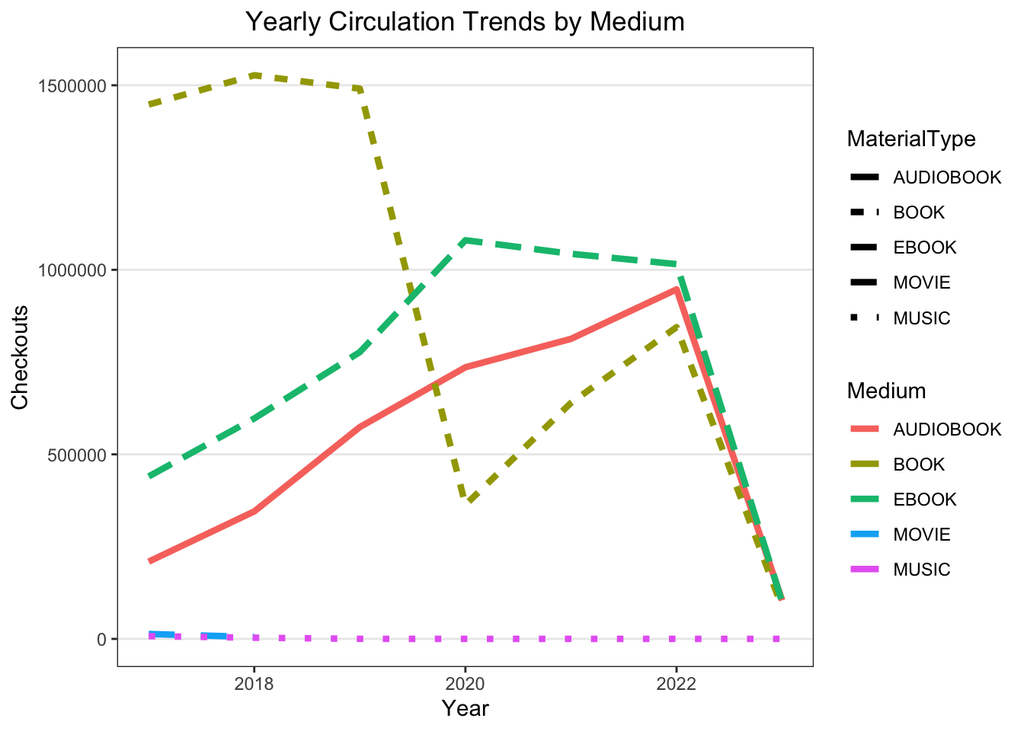

The second chart displays yearly circulation trends by medium, including books, ebooks, audiobooks, music, and movies. I included this chart to compare trends in checkout activity across different material types and provide insights into the evolving preferences of library users.

The inclusion of this chart is essential in providing librarians and book publishers with valuable insights into the circulation trends across different mediums. The data can be used to make informed decisions about the allocation of resources towards digital materials and ensuring that the library collection meets the evolving needs and preferences of library users.

Overall, the second chart provides crucial information regarding the popularity of different material types and the shift towards digital media among library users. The data can assist libraries and publishers in making data-driven decisions about their collection and resource allocation to meet the changing needs of their patrons.

### Chart 3: Total Checkouts of The Great Gatsby by Month

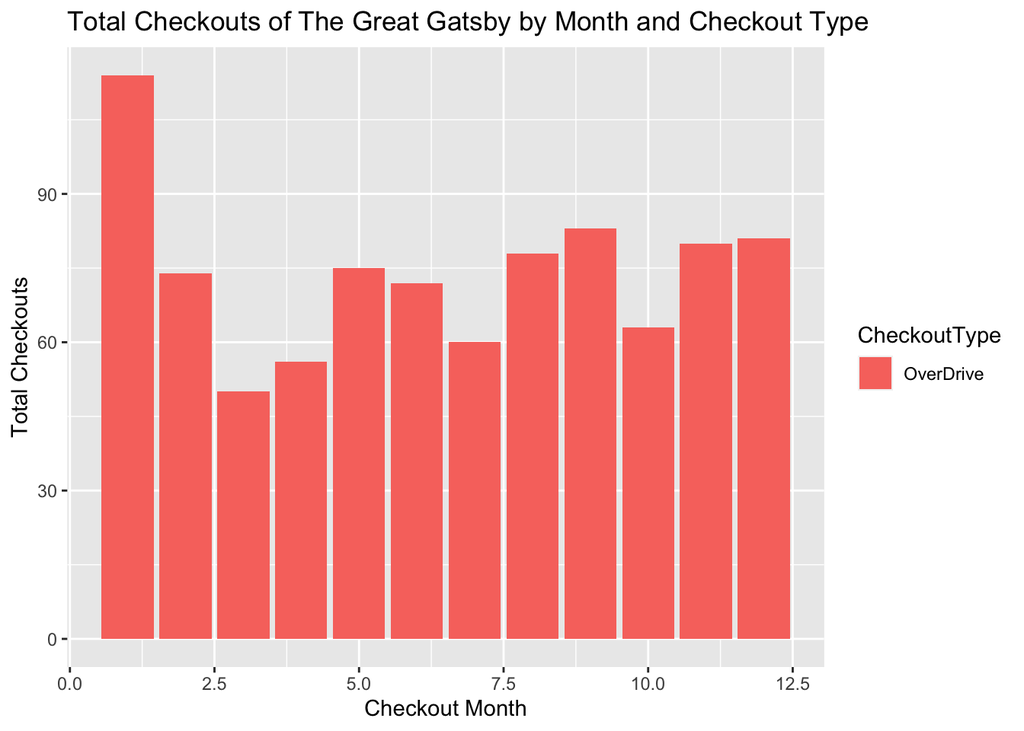

The inclusion of the third chart in the analysis is essential in providing valuable insights into the popularity of “The Great Gatsby” and its checkout patterns by month and checkout type. The chart displays a bar graph with the x-axis representing the checkout month, the y-axis representing the total number of checkouts, and the bars colored by checkout type.

The information provided by this chart can be valuable to librarians and book publishers in understanding the demand and popularity of a specific book. It can also help them tailor their strategies accordingly, such as promoting a declining book through targeted marketing campaigns or offering it in different formats like audiobooks or e-books.

Additionally, understanding the checkout patterns by month and checkout type can help librarians manage their inventory and resources better. By observing a surge in demand for a book during a particular month, they can plan their stock accordingly to ensure availability for readers. If they notice a large number of checkouts being made through online channels, they can improve their online catalog and services to cater to the changing needs and preferences of their patrons.

Overall, the third chart in the analysis provides valuable insights into the popularity and checkout patterns of “The Great Gatsby,” which can assist libraries and publishers in making data-driven decisions to improve their services and meet the evolving needs of their readers.